# Developing an AI application

Going forward, AI algorithms will be incorporated into more and more everyday applications. For example, you might want to include an image classifier in a smart phone app. To do this, you'd use a deep learning model trained on hundreds of thousands of images as part of the overall application architecture. A large part of software development in the future will be using these types of models as common parts of applications.

In this project, you'll train an image classifier to recognize different species of flowers. You can imagine using something like this in a phone app that tells you the name of the flower your camera is looking at. In practice you'd train this classifier, then export it for use in your application. We'll be using [this dataset](http://www.robots.ox.ac.uk/~vgg/data/flowers/102/index.html) of 102 flower categories, you can see a few examples below.

[figure not shown]

The project is broken down into multiple steps:

- Load and preprocess the image dataset
- Train the image classifier on your dataset
- Use the trained classifier to predict image content

We'll lead you through each part which you'll implement in Python.

When you've completed this project, you'll have an application that can be trained on any set of labeled images. Here your network will be learning about flowers and end up as a command line application. But, what you do with your new skills depends on your imagination and effort in building a dataset. For example, imagine an app where you take a picture of a car, it tells you what the make and model is, then looks up information about it. Go build your own dataset and make something new.

First up is importing the packages you'll need. It's good practice to keep all the imports at the beginning of your code. As you work through this notebook and find you need to import a package, make sure to add the import up here.

```python
# Imports here
import numpy as np
import time
import copy
import torch
from torch import nn
import torchvision
import torchvision.transforms as transforms
import torch.optim as optim
from torchvision import datasets
import matplotlib.pyplot as plt
from collections import OrderedDict
import torchvision.models as models
from torch.optim import lr_scheduler
import torch.backends.cudnn as cudnn
from PIL import Image
import seaborn as sns

%matplotlib inline
%config InlineBackend.figure_format = 'retina'
```

```python
print("PyTorch Version: ",torch.__version__)
print("Torchvision Version: ",torchvision.__version__)
print("Numpy Version: ", np.__version__)
```

```
PyTorch Version:  1.0.0
Torchvision Version:  0.2.1
Numpy Version:  1.15.4
```

```python
# check if CUDA is available
train_on_gpu = torch.cuda.is_available()

if not train_on_gpu:
    print('CUDA is not available.  Training on CPU ...')

else:
    print('CUDA is available!  Training on GPU ...')

device = torch.device("cuda:0" if torch.cuda.is_available() else "cpu")
```

```
CUDA is available!  Training on GPU ...
```

## Load the data

Here you'll use `torchvision` to load the data ([documentation](http://pytorch.org/docs/0.3.0/torchvision/index.html)). You can [download the data here](https://s3.amazonaws.com/content.udacity-data.com/courses/nd188/flower_data.zip). The dataset is split into two parts, training and validation. For the training, you'll want to apply transformations such as random scaling, cropping, and flipping. This will help the network generalize leading to better performance. If you use a pre-trained network, you'll also need to make sure the input data is resized to 224x224 pixels as required by the networks.

The validation set is used to measure the model's performance on data it hasn't seen yet. For this you don't want any scaling or rotation transformations, but you'll need to resize then crop the images to the appropriate size.

The pre-trained networks available from `torchvision` were trained on the ImageNet dataset where each color channel was normalized separately. For both sets you'll need to normalize the means and standard deviations of the images to what the network expects. For the means, it's `[0.485, 0.456, 0.406]` and for the standard deviations `[0.229, 0.224, 0.225]`, calculated from the ImageNet images. These values will shift each color channel to be centered at 0 and range from -1 to 1.

```python
data_dir = 'flower_data'
train_dir = data_dir + '/train'
valid_dir = data_dir + '/valid'

#Store the directories in a dictionary for later use

directory = {'train': train_dir,
               'valid': valid_dir
              }
#Note that the dictionary keys in directory and data_transforms in next cell must match
```

In order to understand things better, I used this [PyTorch tutorial](https://pytorch.org/tutorials/beginner/transfer_learning_tutorial.html) on transfer learning. Given that we only have training and validation data in this project, it resembles even more the tutorial.  
I also recommend looking at this [Kaggle VGG16 Transfer Learning Post](https://www.kaggle.com/carloalbertobarbano/vgg16-transfer-learning-pytorch) which resembles what we are doing here.

```python
# how many samples per batch to load
batch_size = 24

# number of subprocesses to use for data loading
num_workers = 0



# TODO: Define your transforms for the training and validation sets
#Define separate transforms for training and validation datasets
#Use random resized crop assuming it will yield a better resizing


data_transforms = { 'train': transforms.Compose([transforms.RandomRotation((-45,45)), #takes in tuple
                                                transforms.RandomResizedCrop(224), #random crop
                                                transforms.RandomHorizontalFlip(), #random horiz flip
                                                transforms.RandomVerticalFlip(), #random horiz flip
                                                transforms.RandomAffine((-45,45)), #shearing the image
                                                transforms.ColorJitter(hue=.05, saturation=.05), #change colors
                                                transforms.ToTensor(),
                                                transforms.Normalize(mean=[0.485, 0.456, 0.406],
                                                                    std=[0.229, 0.224, 0.225])]),
                   'valid': transforms.Compose([transforms.RandomResizedCrop(224),
                                               transforms.RandomHorizontalFlip(),
                                               transforms.RandomVerticalFlip(),
                                               transforms.ToTensor(),
                                               transforms.Normalize(mean=[0.485, 0.456, 0.406],
                                                                    std=[0.229, 0.224, 0.225])])
                  }



# TODO: Load the datasets with ImageFolder
image_datasets = {key: datasets.ImageFolder(directory[key],
                                          transform=data_transforms[key]) for key in directory}


# TODO: Using the image datasets and the trainforms, define the dataloaders
dataloaders = {key: torch.utils.data.DataLoader(image_datasets[key], batch_size=batch_size,
                                             shuffle=True) for key in directory}

dataset_sizes = {key: len(image_datasets[key]) for key in directory}
class_names = image_datasets['train'].classes
```

# Visualize Data

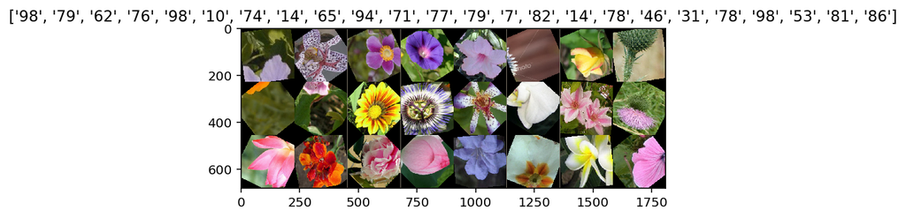

```python
def imshow_sample(inp, title=None):
    """Imshow for Tensor."""
    inp = inp.numpy().transpose((1, 2, 0))
    mean = np.array([0.485, 0.456, 0.406])
    std = np.array([0.229, 0.224, 0.225])
    inp = std * inp + mean
    inp = np.clip(inp, 0, 1)
    plt.imshow(inp)
    if title is not None:
        plt.title(title)
    plt.pause(0.001)  # pause a bit so that plots are updated


# Get a batch of training data
inputs, classes = next(iter(dataloaders['train']))

# Make a grid from batch
out = torchvision.utils.make_grid(inputs)

imshow_sample(out, title=[class_names[x] for x in classes])
```

### Label mapping

You'll also need to load in a mapping from category label to category name. You can find this in the file `cat_to_name.json`. It's a JSON object which you can read in with the [`json` module](https://docs.python.org/2/library/json.html). This will give you a dictionary mapping the integer encoded categories to the actual names of the flowers.

```python
import json

with open('cat_to_name.json', 'r') as f:
    cat_to_name = json.load(f)
```

# Building and training the classifier

Now that the data is ready, it's time to build and train the classifier. As usual, you should use one of the pretrained models from `torchvision.models` to get the image features. Build and train a new feed-forward classifier using those features.

We're going to leave this part up to you. If you want to talk through it with someone, chat with your fellow students! You can also ask questions on the forums or join the instructors in office hours.

Refer to [the rubric](https://review.udacity.com/#!/rubrics/1663/view) for guidance on successfully completing this section. Things you'll need to do:

- Load a [pre-trained network](http://pytorch.org/docs/master/torchvision/models.html) (If you need a starting point, the VGG networks work great and are straightforward to use)
- Define a new, untrained feed-forward network as a classifier, using ReLU activations and dropout
- Train the classifier layers using backpropagation using the pre-trained network to get the features
- Track the loss and accuracy on the validation set to determine the best hyperparameters

We've left a cell open for you below, but use as many as you need. Our advice is to break the problem up into smaller parts you can run separately. Check that each part is doing what you expect, then move on to the next. You'll likely find that as you work through each part, you'll need to go back and modify your previous code. This is totally normal!

When training make sure you're updating only the weights of the feed-forward network. You should be able to get the validation accuracy above 70% if you build everything right. Make sure to try different hyperparameters (learning rate, units in the classifier, epochs, etc) to find the best model. Save those hyperparameters to use as default values in the next part of the project.

```python
# TODO: Build and train your network
```

## VGG19

```python
model = models.vgg19(pretrained=True)
```

```python
#look at the architecture
model
```

```
VGG(
  (features): Sequential(
    (0): Conv2d(3, 64, kernel_size=(3, 3), stride=(1, 1), padding=(1, 1))
    (1): ReLU(inplace)
    (2): Conv2d(64, 64, kernel_size=(3, 3), stride=(1, 1), padding=(1, 1))
    (3): ReLU(inplace)
    (4): MaxPool2d(kernel_size=2, stride=2, padding=0, dilation=1, ceil_mode=False)
    (5): Conv2d(64, 128, kernel_size=(3, 3), stride=(1, 1), padding=(1, 1))
    (6): ReLU(inplace)
    (7): Conv2d(128, 128, kernel_size=(3, 3), stride=(1, 1), padding=(1, 1))
    (8): ReLU(inplace)
    (9): MaxPool2d(kernel_size=2, stride=2, padding=0, dilation=1, ceil_mode=False)
    (10): Conv2d(128, 256, kernel_size=(3, 3), stride=(1, 1), padding=(1, 1))
    (11): ReLU(inplace)
    (12): Conv2d(256, 256, kernel_size=(3, 3), stride=(1, 1), padding=(1, 1))
    (13): ReLU(inplace)
    (14): Conv2d(256, 256, kernel_size=(3, 3), stride=(1, 1), padding=(1, 1))
    (15): ReLU(inplace)
    (16): Conv2d(256, 256, kernel_size=(3, 3), stride=(1, 1), padding=(1, 1))
    (17): ReLU(inplace)
    (18): MaxPool2d(kernel_size=2, stride=2, padding=0, dilation=1, ceil_mode=False)
    (19): Conv2d(256, 512, kernel_size=(3, 3), stride=(1, 1), padding=(1, 1))
    (20): ReLU(inplace)
    (21): Conv2d(512, 512, kernel_size=(3, 3), stride=(1, 1), padding=(1, 1))
    (22): ReLU(inplace)
    (23): Conv2d(512, 512, kernel_size=(3, 3), stride=(1, 1), padding=(1, 1))
    (24): ReLU(inplace)
    (25): Conv2d(512, 512, kernel_size=(3, 3), stride=(1, 1), padding=(1, 1))
    (26): ReLU(inplace)
    (27): MaxPool2d(kernel_size=2, stride=2, padding=0, dilation=1, ceil_mode=False)
    (28): Conv2d(512, 512, kernel_size=(3, 3), stride=(1, 1), padding=(1, 1))
    (29): ReLU(inplace)
    (30): Conv2d(512, 512, kernel_size=(3, 3), stride=(1, 1), padding=(1, 1))
    (31): ReLU(inplace)
    (32): Conv2d(512, 512, kernel_size=(3, 3), stride=(1, 1), padding=(1, 1))
    (33): ReLU(inplace)
    (34): Conv2d(512, 512, kernel_size=(3, 3), stride=(1, 1), padding=(1, 1))
    (35): ReLU(inplace)
    (36): MaxPool2d(kernel_size=2, stride=2, padding=0, dilation=1, ceil_mode=False)
  )
  (classifier): Sequential(
    (0): Linear(in_features=25088, out_features=4096, bias=True)
    (1): ReLU(inplace)
    (2): Dropout(p=0.5)
    (3): Linear(in_features=4096, out_features=4096, bias=True)
    (4): ReLU(inplace)
    (5): Dropout(p=0.5)
    (6): Linear(in_features=4096, out_features=1000, bias=True)
  )
)
```

Look at the final line in the architecture. We have to redefine the classifier to fit our purpose.

We want the output to be consistent with the number of classes we have.

```python
n_class = len(class_names)
```

We will adapt the classifier at the end of the loaded network with to fit our own needs.

```python
classifier= nn.Sequential(OrderedDict([
    ('fc1', nn.Linear(25088, 6272)),
    ('relu', nn.ReLU()),
    ('fc2', nn.Linear(6272, n_class)),
    ('output', nn.LogSoftmax(dim =1))
]))
```

freeze all the network except the final layer.

```python
for param in model.parameters():
    param.requires_grad = False
```

Replace the classifier at the end with the one we defined

```python
model.classifier= classifier
```

```python
#Move tto cuda if available

if train_on_gpu:
    model=model.to(device)
    cudnn.benchmark = True
```

## Train the model

```python
def train_model(model, criterion, optimizer, scheduler, num_epochs=20, device='cuda:0'):
    since = time.time()

    best_model_wts = copy.deepcopy(model.state_dict())
    best_acc = 0.0


    train_losses, test_losses = [], []

    for epoch in range(num_epochs):
        print('Epoch {}/{}'.format(epoch, num_epochs - 1))
        print('-' * 10)

        # Each epoch has a training and validation phase
        for phase in ['train', 'valid']:
            if phase == 'train':
                scheduler.step()
                model.train()  # Set model to training mode
            else:
                model.eval()   # Set model to evaluate mode

            running_loss = 0.0
            running_corrects = 0

            # Iterate over data.
            for inputs, labels in dataloaders[phase]:
                inputs = inputs.to(device)
                labels = labels.to(device)

                # zero the parameter gradients
                optimizer.zero_grad()

                # forward
                # track history if only in train
                with torch.set_grad_enabled(phase == 'train'):
                    outputs = model(inputs)
                    _, preds = torch.max(outputs, 1)
                    loss = criterion(outputs, labels)

                    # backward + optimize only if in training phase
                    if phase == 'train':
                        loss.backward()
                        optimizer.step()

                # statistics
                running_loss += loss.item() * inputs.size(0)
                running_corrects += torch.sum(preds == labels.data)

            epoch_loss = running_loss / dataset_sizes[phase]
            epoch_acc = running_corrects.double() / dataset_sizes[phase]

            print('{} Loss: {:.4f} Acc: {:.4f}'.format(
                phase, epoch_loss, epoch_acc))
            #Save the loss for inference
            if phase=='train':
                train_losses.append(epoch_loss)
            else:
                test_losses.append(epoch_loss)

            # deep copy the model
            if phase == 'valid' and epoch_acc > best_acc:
                best_acc = epoch_acc
                best_model_wts = copy.deepcopy(model.state_dict())

        print()

    time_elapsed = time.time() - since
    print('Training complete in {:.0f}m {:.0f}s'.format(
        time_elapsed // 60, time_elapsed % 60))
    print('Best val Acc: {:4f}'.format(best_acc))

    # load best model weights
    model.load_state_dict(best_model_wts)
    return model, train_losses, test_losses
```

## Train VGG19

Pick the The negative log likelihood loss: [NLL](https://pytorch.org/docs/stable/nn.html#nllloss). Contraty to the transfer learning tutorial, use Adam as an optimizer in lieu of SGD.

```python
#The negative log likelihood loss. It is useful to train a classification problem with C classes.
#Define criterion
criterion = nn.NLLLoss()
```

```python
# Observe that all parameters are being optimized
optimizer = optim.Adam(model.parameters(), lr=0.001)
```

```python
# Decay LR by a factor of 0.1 every 5 epochs
exp_lr_scheduler = lr_scheduler.StepLR(optimizer, step_size=5, gamma=0.1)
```

```python
model_ft, train_losses, test_losses = train_model(model, criterion, optimizer, exp_lr_scheduler,
                       num_epochs=20)
```

```
----------
train Loss: 3.2549 Acc: 0.3222
valid Loss: 1.8931 Acc: 0.5049

----------
train Loss: 1.7826 Acc: 0.5256
valid Loss: 1.6183 Acc: 0.5709

----------
train Loss: 1.5541 Acc: 0.5818
valid Loss: 1.5110 Acc: 0.6137

----------
train Loss: 1.4775 Acc: 0.6073
valid Loss: 1.4333 Acc: 0.6259

----------
train Loss: 1.3705 Acc: 0.6305
valid Loss: 1.3468 Acc: 0.6528

----------
train Loss: 1.1273 Acc: 0.6912
valid Loss: 1.0910 Acc: 0.7103

----------
train Loss: 1.0463 Acc: 0.7103
valid Loss: 1.0906 Acc: 0.7103

----------
train Loss: 1.0247 Acc: 0.7146
valid Loss: 1.0905 Acc: 0.7127

----------
train Loss: 0.9812 Acc: 0.7364
valid Loss: 1.0237 Acc: 0.7372

----------
train Loss: 0.9358 Acc: 0.7431
valid Loss: 1.1713 Acc: 0.7005

```

[output cut: 27 more lines]

```

----------
train Loss: 0.8925 Acc: 0.7566
valid Loss: 1.0583 Acc: 0.7237

----------
train Loss: 0.8830 Acc: 0.7535
valid Loss: 0.9756 Acc: 0.7628

----------
train Loss: 0.8892 Acc: 0.7599
valid Loss: 1.0313 Acc: 0.7176

Training complete in 70m 29s
Best val Acc: 0.762836
```

### VGG19 Inference and Validation

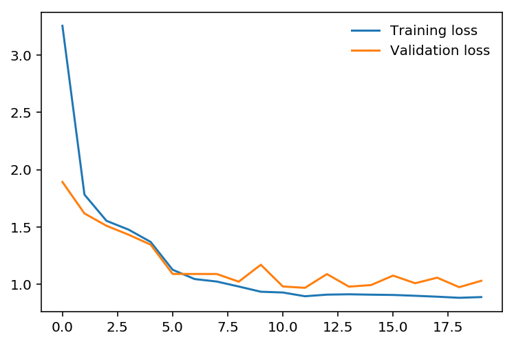

```python
plt.plot(train_losses, label='Training loss')
plt.plot(test_losses, label='Validation loss')
plt.legend(frameon=False)
```

## Train AlexNet

```python
model_alex=models.alexnet(pretrained=True)
```

```python
#Look at AlexNet
model_alex
```

```
AlexNet(
  (features): Sequential(
    (0): Conv2d(3, 64, kernel_size=(11, 11), stride=(4, 4), padding=(2, 2))
    (1): ReLU(inplace)
    (2): MaxPool2d(kernel_size=3, stride=2, padding=0, dilation=1, ceil_mode=False)
    (3): Conv2d(64, 192, kernel_size=(5, 5), stride=(1, 1), padding=(2, 2))
    (4): ReLU(inplace)
    (5): MaxPool2d(kernel_size=3, stride=2, padding=0, dilation=1, ceil_mode=False)
    (6): Conv2d(192, 384, kernel_size=(3, 3), stride=(1, 1), padding=(1, 1))
    (7): ReLU(inplace)
    (8): Conv2d(384, 256, kernel_size=(3, 3), stride=(1, 1), padding=(1, 1))
    (9): ReLU(inplace)
    (10): Conv2d(256, 256, kernel_size=(3, 3), stride=(1, 1), padding=(1, 1))
    (11): ReLU(inplace)
    (12): MaxPool2d(kernel_size=3, stride=2, padding=0, dilation=1, ceil_mode=False)
  )
  (classifier): Sequential(
    (0): Dropout(p=0.5)
    (1): Linear(in_features=9216, out_features=4096, bias=True)
    (2): ReLU(inplace)
    (3): Dropout(p=0.5)
    (4): Linear(in_features=4096, out_features=4096, bias=True)
    (5): ReLU(inplace)
    (6): Linear(in_features=4096, out_features=1000, bias=True)
  )
)
```

```python
classifier_alex= nn.Sequential(OrderedDict([
    ('fc1', nn.Linear(9216, 2304)),
    ('relu', nn.ReLU()),
    ('fc2', nn.Linear(2304, n_class)),
    ('output', nn.LogSoftmax(dim =1))
]))
```

```python
for param in model_alex.parameters():
    param.requires_grad = False
```

```python
model_alex.classifier= classifier_alex
```

```python
# Observe that all parameters are being optimized
optimizer_alex = optim.Adam(model_alex.parameters(), lr=0.001)
```

```python
# Decay LR by a factor of 0.1 every 5 epochs
exp_lr_scheduler_alex = lr_scheduler.StepLR(optimizer_alex, step_size=5, gamma=0.1)
```

```python
#Move to cuda if available
if train_on_gpu:
    model_alex=model_alex.to(device)
    cudnn.benchmark = True
```

```python
model_alex_ft, train_losses_alex, test_losses_alex = train_model(model_alex, criterion,
                                                                 optimizer_alex, exp_lr_scheduler_alex,
                                                                 num_epochs=20)
```

```
----------
train Loss: 2.9683 Acc: 0.3518
valid Loss: 1.7034 Acc: 0.5440

----------
train Loss: 1.7083 Acc: 0.5397
valid Loss: 1.4740 Acc: 0.5954

----------
train Loss: 1.5377 Acc: 0.5885
valid Loss: 1.3801 Acc: 0.6369

----------
train Loss: 1.4471 Acc: 0.6053
valid Loss: 1.2870 Acc: 0.6504

----------
train Loss: 1.3723 Acc: 0.6343
valid Loss: 1.3901 Acc: 0.6345

----------
train Loss: 1.1018 Acc: 0.6949
valid Loss: 1.0657 Acc: 0.7176

----------
train Loss: 1.0376 Acc: 0.7179
valid Loss: 1.0461 Acc: 0.7213

----------
train Loss: 0.9762 Acc: 0.7337
valid Loss: 1.0282 Acc: 0.7347

----------
train Loss: 0.9409 Acc: 0.7462
valid Loss: 0.9620 Acc: 0.7421

----------
train Loss: 0.9100 Acc: 0.7462
valid Loss: 1.1026 Acc: 0.7139

```

[output cut: 23 more lines]

```

----------
train Loss: 0.8948 Acc: 0.7581
valid Loss: 0.9662 Acc: 0.7555

----------
train Loss: 0.8494 Acc: 0.7625
valid Loss: 0.9815 Acc: 0.7482

----------
train Loss: 0.8737 Acc: 0.7541
valid Loss: 0.9742 Acc: 0.7543

Training complete in 33m 34s
Best val Acc: 0.755501
```

### AlexNet Inference and Validation

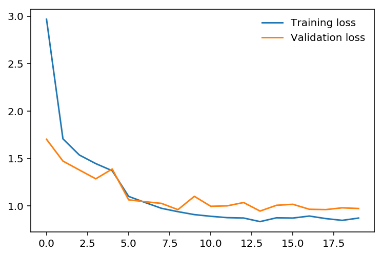

```python
plt.plot(train_losses_alex, label='Training loss')
plt.plot(test_losses_alex, label='Validation loss')
plt.legend(frameon=False)
```

## Save the checkpoint

Now that your network is trained, save the model so you can load it later for making predictions. You probably want to save other things such as the mapping of classes to indices which you get from one of the image datasets: `image_datasets['train'].class_to_idx`. You can attach this to the model as an attribute which makes inference easier later on.

`model.class_to_idx = image_datasets['train'].class_to_idx`

Remember that you'll want to completely rebuild the model later so you can use it for inference. Make sure to include any information you need in the checkpoint. If you want to load the model and keep training, you'll want to save the number of epochs as well as the optimizer state, `optimizer.state_dict`. You'll likely want to use this trained model in the next part of the project, so best to save it now.

```python
# TODO: Save the checkpoint
```

Refer to [Saving and Loading Models](https://pytorch.org/tutorials/beginner/saving_loading_models.html) for tutorial

## Save VGG19

```python
model_ft=model_ft.to('cpu')
```

```python
model_ft.class_to_idx=image_datasets['train'].class_to_idx
```

```python
model_dict={'arch': 'vgg19',
            'state_dict': model_ft.state_dict(),
            'class_to_idx': model_ft.class_to_idx,
            'weights': model_ft.features}
```

```python
torch.save(model_dict,'vgg19.pth')
```

## Save AlexNet

```python
model_alex_ft=model_alex_ft.to('cpu')
```

```python
model_alex_ft.class_to_idx=image_datasets['train'].class_to_idx
```

```python
model_alex_dict={'arch': 'alexnet',
            'state_dict': model_alex_ft.state_dict(),
            'class_to_idx': model_alex_ft.class_to_idx,
            'weights': model_alex_ft.features}
```

```python
torch.save(model_alex_dict,'alexnet.pth')
```

## Loading the checkpoint

At this point it's good to write a function that can load a checkpoint and rebuild the model. That way you can come back to this project and keep working on it without having to retrain the network.

```python
# TODO: Write a function that loads a checkpoint and rebuilds the model
```

```python
def load_model(checkpoint_path):
    checkpoint = torch.load(checkpoint_path)


    #Load the model
    if checkpoint['arch'] == 'vgg19':
        model = models.vgg19(pretrained=True)

        classifier= nn.Sequential(OrderedDict([
                          ('fc1', nn.Linear(25088, 6272)),
                          ('relu', nn.ReLU()),
                          ('fc2', nn.Linear(6272, 102)),
                          ('output', nn.LogSoftmax(dim=1))
                          ]))

    if checkpoint['arch']=='alexnet':
        model=models.alexnet(pretrained=True)

        classifier= nn.Sequential(OrderedDict([
            ('fc1', nn.Linear(9216, 2304)),
            ('relu', nn.ReLU()),
            ('fc2', nn.Linear(2304, 102)),
            ('output', nn.LogSoftmax(dim =1))]))

    model.classifier=classifier

    for param in model.parameters():
        param.requires_grad = False


    model.load_state_dict(checkpoint['state_dict'], strict=True)

    #load the classes
    model.class_to_idx = checkpoint['class_to_idx']




    return model
```

## Load VGG19

```python
model_vgg19 = load_model('vgg19.pth')
```

```python
#See what we have
model_vgg19
```

```
VGG(
  (features): Sequential(
    (0): Conv2d(3, 64, kernel_size=(3, 3), stride=(1, 1), padding=(1, 1))
    (1): ReLU(inplace)
    (2): Conv2d(64, 64, kernel_size=(3, 3), stride=(1, 1), padding=(1, 1))
    (3): ReLU(inplace)
    (4): MaxPool2d(kernel_size=2, stride=2, padding=0, dilation=1, ceil_mode=False)
    (5): Conv2d(64, 128, kernel_size=(3, 3), stride=(1, 1), padding=(1, 1))
    (6): ReLU(inplace)
    (7): Conv2d(128, 128, kernel_size=(3, 3), stride=(1, 1), padding=(1, 1))
    (8): ReLU(inplace)
    (9): MaxPool2d(kernel_size=2, stride=2, padding=0, dilation=1, ceil_mode=False)
    (10): Conv2d(128, 256, kernel_size=(3, 3), stride=(1, 1), padding=(1, 1))
    (11): ReLU(inplace)
    (12): Conv2d(256, 256, kernel_size=(3, 3), stride=(1, 1), padding=(1, 1))
    (13): ReLU(inplace)
    (14): Conv2d(256, 256, kernel_size=(3, 3), stride=(1, 1), padding=(1, 1))
    (15): ReLU(inplace)
    (16): Conv2d(256, 256, kernel_size=(3, 3), stride=(1, 1), padding=(1, 1))
    (17): ReLU(inplace)
    (18): MaxPool2d(kernel_size=2, stride=2, padding=0, dilation=1, ceil_mode=False)
    (19): Conv2d(256, 512, kernel_size=(3, 3), stride=(1, 1), padding=(1, 1))
    (20): ReLU(inplace)
    (21): Conv2d(512, 512, kernel_size=(3, 3), stride=(1, 1), padding=(1, 1))
    (22): ReLU(inplace)
    (23): Conv2d(512, 512, kernel_size=(3, 3), stride=(1, 1), padding=(1, 1))
    (24): ReLU(inplace)
    (25): Conv2d(512, 512, kernel_size=(3, 3), stride=(1, 1), padding=(1, 1))
    (26): ReLU(inplace)
    (27): MaxPool2d(kernel_size=2, stride=2, padding=0, dilation=1, ceil_mode=False)
    (28): Conv2d(512, 512, kernel_size=(3, 3), stride=(1, 1), padding=(1, 1))
    (29): ReLU(inplace)
    (30): Conv2d(512, 512, kernel_size=(3, 3), stride=(1, 1), padding=(1, 1))
    (31): ReLU(inplace)
    (32): Conv2d(512, 512, kernel_size=(3, 3), stride=(1, 1), padding=(1, 1))
    (33): ReLU(inplace)
    (34): Conv2d(512, 512, kernel_size=(3, 3), stride=(1, 1), padding=(1, 1))
    (35): ReLU(inplace)
    (36): MaxPool2d(kernel_size=2, stride=2, padding=0, dilation=1, ceil_mode=False)
  )
  (classifier): Sequential(
    (fc1): Linear(in_features=25088, out_features=6272, bias=True)
    (relu): ReLU()
    (fc2): Linear(in_features=6272, out_features=102, bias=True)
    (output): LogSoftmax()
  )
)
```

## Load AlexNet

```python
model_alex = load_model('alexnet.pth')
```

```python
#See what we have
model_alex
```

```
AlexNet(
  (features): Sequential(
    (0): Conv2d(3, 64, kernel_size=(11, 11), stride=(4, 4), padding=(2, 2))
    (1): ReLU(inplace)
    (2): MaxPool2d(kernel_size=3, stride=2, padding=0, dilation=1, ceil_mode=False)
    (3): Conv2d(64, 192, kernel_size=(5, 5), stride=(1, 1), padding=(2, 2))
    (4): ReLU(inplace)
    (5): MaxPool2d(kernel_size=3, stride=2, padding=0, dilation=1, ceil_mode=False)
    (6): Conv2d(192, 384, kernel_size=(3, 3), stride=(1, 1), padding=(1, 1))
    (7): ReLU(inplace)
    (8): Conv2d(384, 256, kernel_size=(3, 3), stride=(1, 1), padding=(1, 1))
    (9): ReLU(inplace)
    (10): Conv2d(256, 256, kernel_size=(3, 3), stride=(1, 1), padding=(1, 1))
    (11): ReLU(inplace)
    (12): MaxPool2d(kernel_size=3, stride=2, padding=0, dilation=1, ceil_mode=False)
  )
  (classifier): Sequential(
    (fc1): Linear(in_features=9216, out_features=2304, bias=True)
    (relu): ReLU()
    (fc2): Linear(in_features=2304, out_features=102, bias=True)
    (output): LogSoftmax()
  )
)
```

# Inference for classification

Now you'll write a function to use a trained network for inference. That is, you'll pass an image into the network and predict the class of the flower in the image. Write a function called `predict` that takes an image and a model, then returns the top $K$ most likely classes along with the probabilities. It should look like

```
probs, classes = predict(image_path, model)
print(probs)
print(classes)
> [ 0.01558163  0.01541934  0.01452626  0.01443549  0.01407339]
> ['70', '3', '45', '62', '55']
```

First you'll need to handle processing the input image such that it can be used in your network.

## Image Preprocessing

You'll want to use `PIL` to load the image ([documentation](https://pillow.readthedocs.io/en/latest/reference/Image.html)). It's best to write a function that preprocesses the image so it can be used as input for the model. This function should process the images in the same manner used for training.

First, resize the images where the shortest side is 256 pixels, keeping the aspect ratio. This can be done with the [`thumbnail`](http://pillow.readthedocs.io/en/3.1.x/reference/Image.html#PIL.Image.Image.thumbnail) or [`resize`](http://pillow.readthedocs.io/en/3.1.x/reference/Image.html#PIL.Image.Image.thumbnail) methods. Then you'll need to crop out the center 224x224 portion of the image.

Color channels of images are typically encoded as integers 0-255, but the model expected floats 0-1. You'll need to convert the values. It's easiest with a Numpy array, which you can get from a PIL image like so `np_image = np.array(pil_image)`.

As before, the network expects the images to be normalized in a specific way. For the means, it's `[0.485, 0.456, 0.406]` and for the standard deviations `[0.229, 0.224, 0.225]`. You'll want to subtract the means from each color channel, then divide by the standard deviation.

And finally, PyTorch expects the color channel to be the first dimension but it's the third dimension in the PIL image and Numpy array. You can reorder dimensions using [`ndarray.transpose`](https://docs.scipy.org/doc/numpy-1.13.0/reference/generated/numpy.ndarray.transpose.html). The color channel needs to be first and retain the order of the other two dimensions.

Note the Pillow library [Coordinate System](https://pillow.readthedocs.io/en/3.3.x/handbook/concepts.html#coordinate-system):  
The Python Imaging Library uses a Cartesian pixel coordinate system, with (0,0) in the upper left corner. Note that the coordinates refer to the implied pixel corners; the centre of a pixel addressed as (0, 0) actually lies at (0.5, 0.5).

```python
#function to crop image
def crop_image(pil_image, new_width=224, new_height=224):

    width, height = pil_image.size

    left = (width - new_width)/2
    bottom = (height - new_height)/2
    top = (height + new_height)/2
    right = (width + new_width)/2

    box=(left, bottom, right, top)


    cropped_image=pil_image.crop(box)

    return cropped_image
```

```python
def process_image(image_path):
    ''' Scales, crops, and normalizes a PIL image for a PyTorch model,
        returns an Numpy array
    '''

    # TODO: Process a PIL image for use in a PyTorch model
    image= Image.open(image_path)


    #Scale the image using the smaller dimension as the resize argument in the tuple
    #Note that thumbnail modifies the Image object in place
    width, height=image.size
    if width>height:
        image.thumbnail((2e6, 256))
    else:
        image.thumbnail((256, 2e6))

    #crop the image
    image=crop_image(image)

    #normalize
    image=np.array(image)/255

    mean=np.array([0.485, 0.456, 0.406])
    std=np.array([0.229, 0.224, 0.225])
    image= (image-mean)/std

    #reorder dimensions
    image=image.transpose((2,0,1))

    return image
```

To check your work, the function below converts a PyTorch tensor and displays it in the notebook. If your `process_image` function works, running the output through this function should return the original image (except for the cropped out portions).

```python
def imshow(image, ax=None, title=None):
    """Imshow for Tensor."""
    if ax is None:
        fig, ax = plt.subplots()

    # PyTorch tensors assume the color channel is the first dimension
    # but matplotlib assumes is the third dimension
    image = image.transpose((1, 2, 0))

    # Undo preprocessing
    mean = np.array([0.485, 0.456, 0.406])
    std = np.array([0.229, 0.224, 0.225])
    image = std * image + mean

    # Image needs to be clipped between 0 and 1 or it looks like noise when displayed
    image = np.clip(image, 0, 1)

    ax.imshow(image)

    return ax
```

```python
#Test it out on a random image
test_image= 'flower_data/train/25/image_06598.jpg'
```

```python
image=process_image(test_image)
```

[figure not shown]

```python
imshow(image)
```

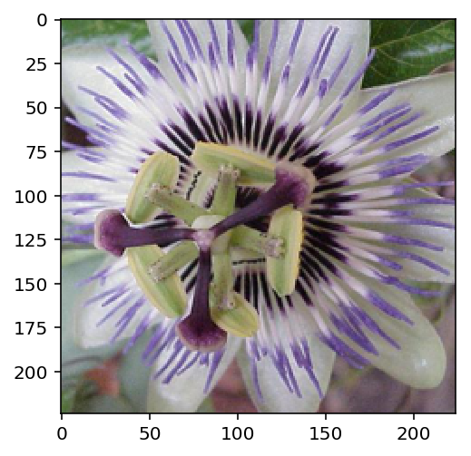

```python
#Try it out on another image just for sanity check
image_1='flower_data/train/77/image_00093.jpg'
image_1=process_image(image_1)
imshow(image_1)
```

## Class Prediction

Once you can get images in the correct format, it's time to write a function for making predictions with your model. A common practice is to predict the top 5 or so (usually called top-$K$) most probable classes. You'll want to calculate the class probabilities then find the $K$ largest values.

To get the top $K$ largest values in a tensor use [`x.topk(k)`](http://pytorch.org/docs/master/torch.html#torch.topk). This method returns both the highest `k` probabilities and the indices of those probabilities corresponding to the classes. You need to convert from these indices to the actual class labels using `class_to_idx` which hopefully you added to the model or from an `ImageFolder` you used to load the data (see here). Make sure to invert the dictionary so you get a mapping from index to class as well.

Again, this method should take a path to an image and a model checkpoint, then return the probabilities and classes.

```
probs, classes = predict(image_path, model)
print(probs)
print(classes)
> [ 0.01558163  0.01541934  0.01452626  0.01443549  0.01407339]
> ['70', '3', '45', '62', '55']
```

I found this [post](https://discuss.pytorch.org/t/how-to-extract-probabilities/2720/2) to be particularily useful for the VGG19 model, and this other post for [torch tensor](https://discuss.pytorch.org/t/converting-the-list-of-numpy-image-into-torch-tensor/8015). Finally there are alsos posts from [CIFAR-10](https://github.com/udacity/deep-learning-v2-pytorch/blob/master/convolutional-neural-networks/cifar-cnn/cifar10_cnn_solution.ipynb) and [Transfer Learning](https://github.com/udacity/deep-learning-v2-pytorch/blob/master/transfer-learning/Transfer_Learning_Solution.ipynb) from the [Udacity PyTorch](https://github.com/udacity/deep-learning-v2-pytorch) repository.

```python
def predict(image_path, model, topk=5, device='cuda:0'):
    ''' Predict the class (or classes) of an image using a trained deep learning model.
    '''

    # TODO: Implement the code to predict the class from an image file

    #process image for pytorch
    image=process_image(image_path)

    #convert to torch tensor
    tensor_image=torch.from_numpy(image).type(torch.FloatTensor)

    #Return a tensor with all the dimensions of input of size 1 removed
    squeeze_image= tensor_image.unsqueeze(0)

    #move image to cuda device
    squeeze_image=squeeze_image.cuda()

    #move the model to cuda
    model.to(device)

    #extract probability
    proba=torch.exp(model.forward(squeeze_image))

    #Return the k largest elements of the given input tensor along a given dimension
    top_probas, top_labels= proba.topk(topk)

    #move top probabilies and top labels back to cpu
    top_probas=top_probas.cpu()
    top_labels=top_labels.cpu()

    #transform variable into numpy
    top_probas= top_probas.detach().numpy().tolist()[0]
    top_labels=top_labels.detach().numpy().tolist()[0]

    #convert indices to the actual class labels using
    idx_to_class={val: key for key, val in model.class_to_idx.items()}

    #Note that we make the label an integer to match with the existing keys
    top_labels=[idx_to_class[int(lab)] for lab in top_labels]
    top_flowers= [cat_to_name[idx_to_class[int(label)]] for label in top_labels]

    return top_probas, top_labels, top_flowers
```

## Sanity Checking

Now that you can use a trained model for predictions, check to make sure it makes sense. Even if the validation accuracy is high, it's always good to check that there aren't obvious bugs. Use `matplotlib` to plot the probabilities for the top 5 classes as a bar graph, along with the input image. It should look like this:

[figure not shown]

You can convert from the class integer encoding to actual flower names with the `cat_to_name.json` file (should have been loaded earlier in the notebook). To show a PyTorch tensor as an image, use the `imshow` function defined above.

```python
# TODO: Display an image along with the top 5 classes
```

```python
def plot_flower(path, model):

    #plot area
    plt.figure(figsize=(6, 6))
    ax=plt.subplot(2, 1, 1)

    #flower files are set up as flower_data/train/xx/blablabla.jpg
    #we want to extract the xx label for the flower number
    flower_number=path.split('/')[2]
    image_title = cat_to_name[flower_number]

    #process the image
    image=process_image(path)

    #show the image
    imshow(image, ax, title = image_title)

    #predict top 5 flowers
    top_probas, top_labels, top_flowers=predict(path, model)

    #plot top 5 predictions
    plt.subplot(2, 1, 2)
    sns.barplot(x=top_probas, y=top_flowers, color=sns.color_palette()[0])

    #show everything
    plt.show()
```

## Predictions Using VGG19

```python
#test it out on a flower
flower='flower_data/train/101/image_07945.jpg'
```

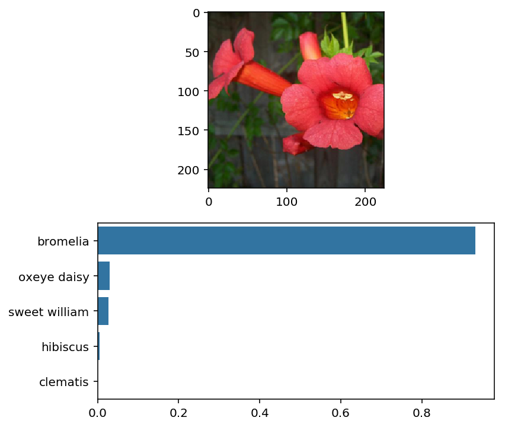

```python
plot_flower(flower, model_vgg19)
```

```python
flower_2='flower_data/train/65/image_03260.jpg'
```

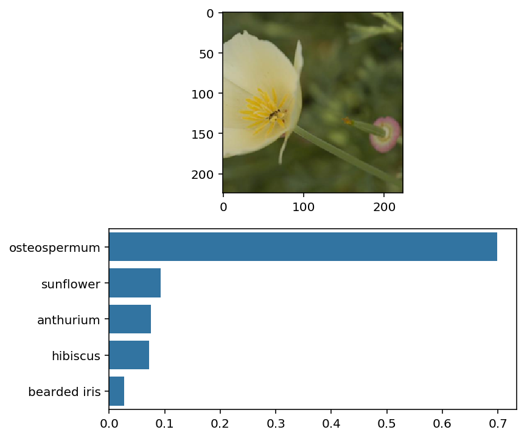

```python
plot_flower(flower_2, model_vgg19)
```

```python
flower_3='flower_data/valid/98/image_07810.jpg'
```

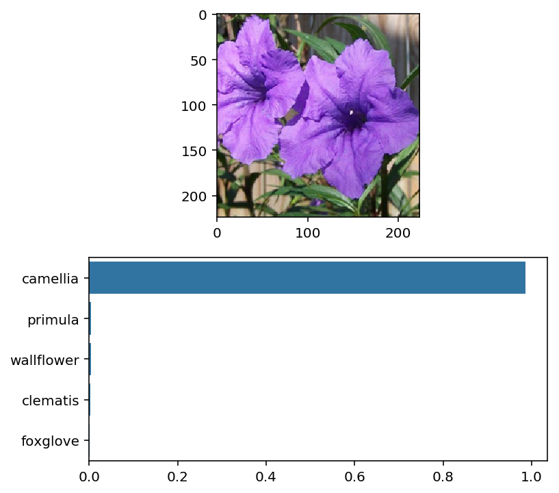

```python
plot_flower(flower_3, model_vgg19)
```

## Predictions Using AlexNet

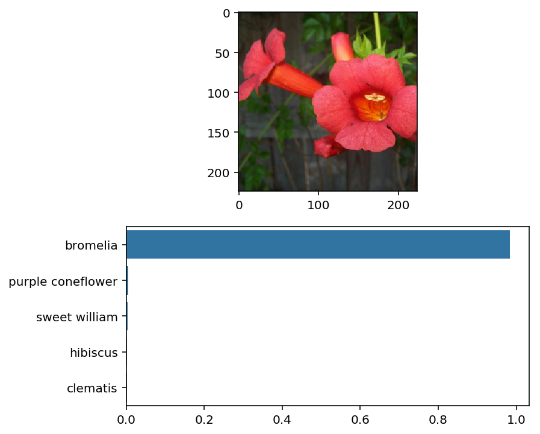

```python
plot_flower(flower, model_alex)
```

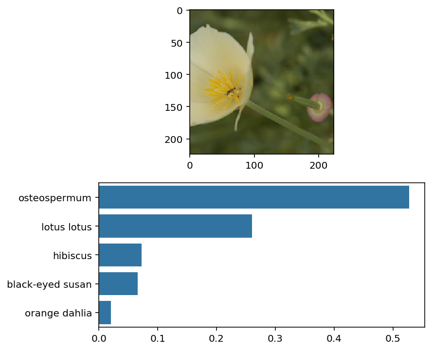

```python
plot_flower(flower_2, model_alex)
```

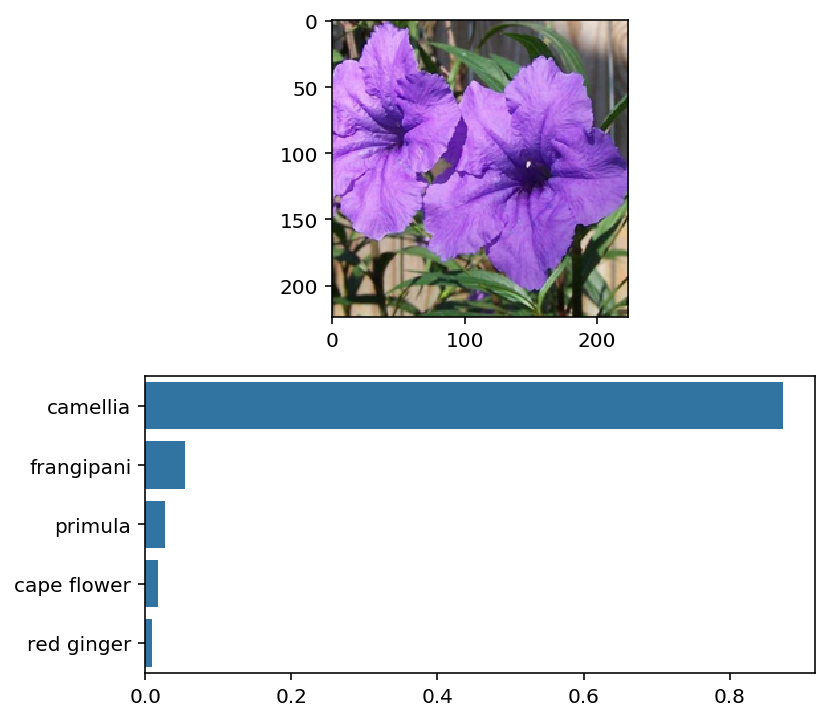

```python
plot_flower(flower_3, model_alex)
```

# ResNet

This is an exercise based on this post on [Finetuning Torchvision Models](https://pytorch.org/tutorials/beginner/finetuning_torchvision_models_tutorial.html)

```python
# Number of classes in the dataset
num_classes = n_class
```

```python
# Models to choose from [resnet, alexnet, vgg, squeezenet, densenet, inception]
model_name = "resnet"
```

```python
# Batch size for training (change depending on how much memory you have)
batch_size = 10
```

```python
# Number of epochs to train for
num_epochs = 15
```

```python
# Flag for feature extracting. When False, we finetune the whole model,
#   when True we only update the reshaped layer params
feature_extract = True
```

```python
def set_parameter_requires_grad(model, feature_extracting):
    if feature_extracting:
        for param in model.parameters():
            param.requires_grad = False
```

```python
def train_model(model, dataloaders, criterion, optimizer, num_epochs=20, is_inception=False, device='cuda:0'):
    since = time.time()

    val_acc_history = []
    train_acc_history=[]

    model=model.to(device)

    best_model_wts = copy.deepcopy(model.state_dict())
    best_acc = 0.0

    for epoch in range(num_epochs):
        print('Epoch {}/{}'.format(epoch, num_epochs - 1))
        print('-' * 10)

        # Each epoch has a training and validation phase
        for phase in ['train', 'valid']:
            if phase == 'train':
                model.train()  # Set model to training mode
            else:
                model.eval()   # Set model to evaluate mode

            running_loss = 0.0
            running_corrects = 0

            # Iterate over data.
            for inputs, labels in dataloaders[phase]:
                inputs = inputs.to(device)
                labels = labels.to(device)

                # zero the parameter gradients
                optimizer.zero_grad()

                # forward
                # track history if only in train
                with torch.set_grad_enabled(phase == 'train'):
                    # Get model outputs and calculate loss
                    # Special case for inception because in training it has an auxiliary output. In train
                    #   mode we calculate the loss by summing the final output and the auxiliary output
                    #   but in testing we only consider the final output.
                    if is_inception and phase == 'train':
                        # From https://discuss.pytorch.org/t/how-to-optimize-inception-model-with-auxiliary-classifiers/7958
                        outputs, aux_outputs = model(inputs)
                        loss1 = criterion(outputs, labels)
                        loss2 = criterion(aux_outputs, labels)
                        loss = loss1 + 0.4*loss2
                    else:
                        outputs = model(inputs)
                        loss = criterion(outputs, labels)

                    _, preds = torch.max(outputs, 1)

                    # backward + optimize only if in training phase
                    if phase == 'train':
                        loss.backward()
                        optimizer.step()

                # statistics
                running_loss += loss.item() * inputs.size(0)
                running_corrects += torch.sum(preds == labels.data)

            epoch_loss = running_loss / len(dataloaders[phase].dataset)
            epoch_acc = running_corrects.double() / len(dataloaders[phase].dataset)

            print('{} Loss: {:.4f} Acc: {:.4f}'.format(phase, epoch_loss, epoch_acc))

            # deep copy the model
            if phase == 'valid' and epoch_acc > best_acc:
                best_acc = epoch_acc
                best_model_wts = copy.deepcopy(model.state_dict())
            if phase == 'valid':
                val_acc_history.append(epoch_acc)
            else:
                train_acc_history.append(epoch_acc)

        print()

    time_elapsed = time.time() - since
    print('Training complete in {:.0f}m {:.0f}s'.format(time_elapsed // 60, time_elapsed % 60))
    print('Best val Acc: {:4f}'.format(best_acc))

    # load best model weights
    model.load_state_dict(best_model_wts)
    return model, val_acc_history, train_acc_history
```

```python
def initialize_model(model_name, num_classes, feature_extract, use_pretrained=True):
    # Initialize these variables which will be set in this if statement. Each of these
    #   variables is model specific.
    model_ft = None
    input_size = 0

    if model_name == "resnet":
        """ Resnet152
        """
        model_ft = models.resnet152(pretrained=use_pretrained)
        set_parameter_requires_grad(model_ft, feature_extract)
        num_ftrs = model_ft.fc.in_features
        model_ft.fc = nn.Linear(num_ftrs, num_classes)
        input_size = 224

    elif model_name == "alexnet":
        """ Alexnet
        """
        model_ft = models.alexnet(pretrained=use_pretrained)
        set_parameter_requires_grad(model_ft, feature_extract)
        num_ftrs = model_ft.classifier[6].in_features
        model_ft.classifier[6] = nn.Linear(num_ftrs,num_classes)
        input_size = 224

    elif model_name == "vgg":
        """ VGG11_bn
        """
        model_ft = models.vgg11_bn(pretrained=use_pretrained)
        set_parameter_requires_grad(model_ft, feature_extract)
        num_ftrs = model_ft.classifier[6].in_features
        model_ft.classifier[6] = nn.Linear(num_ftrs,num_classes)
        input_size = 224

    elif model_name == "squeezenet":
        """ Squeezenet
        """
        model_ft = models.squeezenet1_0(pretrained=use_pretrained)
        set_parameter_requires_grad(model_ft, feature_extract)
        model_ft.classifier[1] = nn.Conv2d(512, num_classes, kernel_size=(1,1), stride=(1,1))
        model_ft.num_classes = num_classes
        input_size = 224

    elif model_name == "densenet":
        """ Densenet
        """
        model_ft = models.densenet121(pretrained=use_pretrained)
        set_parameter_requires_grad(model_ft, feature_extract)
        num_ftrs = model_ft.classifier.in_features
        model_ft.classifier = nn.Linear(num_ftrs, num_classes)
        input_size = 224

    elif model_name == "inception":
        """ Inception v3
        Be careful, expects (299,299) sized images and has auxiliary output
        """
        model_ft = models.inception_v3(pretrained=use_pretrained)
        set_parameter_requires_grad(model_ft, feature_extract)
        # Handle the auxilary net
        num_ftrs = model_ft.AuxLogits.fc.in_features
        model_ft.AuxLogits.fc = nn.Linear(num_ftrs, num_classes)
        # Handle the primary net
        num_ftrs = model_ft.fc.in_features
        model_ft.fc = nn.Linear(num_ftrs,num_classes)
        input_size = 299

    else:
        print("Invalid model name, exiting...")
        exit()

    return model_ft, input_size
```

```python
# Initialize the model for this run
model_resnet, input_size = initialize_model(model_name, num_classes, feature_extract, use_pretrained=True)
```

```python
# Send the model to GPU
model_resnet = model_resnet.to(device)
```

```python
# Gather the parameters to be optimized/updated in this run. If we are
#  finetuning we will be updating all parameters. However, if we are
#  doing feature extract method, we will only update the parameters
#  that we have just initialized, i.e. the parameters with requires_grad
#  is True.
params_to_update = model_resnet.parameters()
print("Params to learn:")
if feature_extract:
    params_to_update = []
    for name,param in model_resnet.named_parameters():
        if param.requires_grad == True:
            params_to_update.append(param)
            print("\t",name)
else:
    for name,param in model_resnet.named_parameters():
        if param.requires_grad == True:
            print("\t",name)

# Observe that all parameters are being optimized
optimizer_resnet = optim.SGD(params_to_update, lr=0.001, momentum=0.9)
```

```
Params to learn:
	 fc.weight
	 fc.bias
```

```python
# Train and evaluate
model_resnet_ft, val_acc_resnet, test_acc_resnet = train_model(model_resnet, dataloaders, criterion,
                                                               optimizer_resnet, num_epochs=num_epochs,
                                                               is_inception=(False))
```

[output not shown]

```python
model_resnet_ft=model_resnet_ft.to('cpu')
```

```python
model_resnet_ft.class_to_idx=image_datasets['train'].class_to_idx
```

```python
model_dict_resnet={'arch': 'resnet',
            'state_dict': model_resnet_ft.state_dict(),
            'class_to_idx': model_resnet_ft.class_to_idx,
            'weights': model_resnet_ft.features}
```

```python
torch.save(model_dict_resnet,'resnet152.pth')
```

```python
plot_flower(flower_3, model_resnet_ft)
```

[output not shown]